# Goal : Predict the manner in which exercises were performed

Background: Using devices such as Jawbone Up, Nike FuelBand, and Fitbit it is now possible to collect a large amount of data about personal activity relatively inexpensively. These type of devices are part of the quantified self movement - a group of enthusiasts who take measurements about themselves regularly to improve their health, to find patterns in their behavior, or because they are tech geeks. One thing that people regularly do is quantify how much of a particular activity they do, but they rarely quantify how well they do it.

In this project, our goal will be to use data from accelerometers on the belt, forearm, arm, and dumbell of 6 participants. They were asked to perform barbell lifts correctly and incorrectly in 5 different ways.

- exactly according to the specification (Class A)
- throwing the elbows to the front (Class B)
- lifting the dumbbell only halfway (Class C)
- lowering the dumbbell only halfway (Class D)
- throwing the hips to the front (Class E)

We will identify how the test objects (participarnts) performed exercises and categorize the findings in one of these 5 levels.

Data is sourced from http://groupware.les.inf.puc-rio.br/har

```r
setInternet2(use = TRUE)
ftest   <- 'pml-test.csv'
testurl <- 'http://d396qusza40orc.cloudfront.net/predmachlearn/pml-testing.csv'

ftrain   <- 'pml-training.csv'
trainurl <- 'http://d396qusza40orc.cloudfront.net/predmachlearn/pml-training.csv'

if (!file.exists(ftest)){
        download.file(testurl, ftest)
}
if (!file.exists(ftrain)){
        download.file(trainurl, ftrain)
}

trainingset <- read.csv(ftrain, header=TRUE, sep=",", as.is = TRUE, na.strings=c("NA","", "#DIV/0!"))
testingset  <- read.csv(ftest, header=TRUE, sep=",", as.is = TRUE, na.strings=c("NA","", "#DIV/0!"))
```

```r
#check dimensions
dim(trainingset) #shows 19622 rows and 160 columns
```

```
## [1] 19622   160
```

```r
dim(testingset)  #shows 20    rows and 160 columns
```

```
## [1]  20 160
```

##### Exploratoy data analysis

You can clearly see different levels. No outliers or erroneous data.

```r
# this will give you some idea about diff factors and bar plot
summary(factor(trainingset$classe))
```

```
##    A    B    C    D    E
## 5580 3797 3422 3216 3607
```

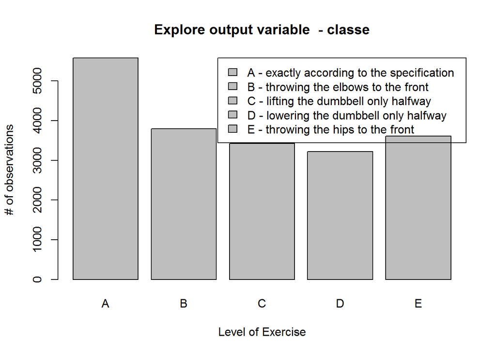

```r
barplot(table(trainingset$classe), main = "Explore output variable  - classe", xlab="Level of Exercise", ylab="# of observations", legend.text= c("A - exactly according to the specification", "B - throwing the elbows to the front", "C - lifting the dumbbell only halfway", "D - lowering the dumbbell only halfway", "E - throwing the hips to the front"), args.legend = list(x = "topright") )
```

##### Load libraries, set seed, remove unwanted columns

```r
set.seed(121)
#removing unwanted columns
trainingset   <-trainingset[,-c(1:7)]
testingset <-testingset[,-c(1:7)]

#removing columns with all the missing values
trainingset<-trainingset[,colSums(is.na(trainingset)) == 0]
testingset <-testingset[,colSums(is.na(testingset)) == 0]

#check the new sets, note that the columns dropped to 53
dim(trainingset) #shows 19622 rows and 53 columns
```

```
## [1] 19622    53
```

```r
dim(testingset)  #shows 20    rows and 53 columns
```

```
## [1] 20 53
```

##### Partitioning the training data set to allow cross-validation

```r
subsamples <- createDataPartition(y=trainingset$classe, p=0.75, list=FALSE)
subTraining <- trainingset[subsamples, ]
subTesting <- trainingset[-subsamples, ]

# Confirm that there are still 53 columns!
dim(subTraining)
```

```
## [1] 14718    53
```

```r
dim(subTesting)
```

```
## [1] 4904   53
```

```r
#head(subTraining)
```

##### Find correlated predictors using principle components analysis

Dark blue or dark red columns are highly correlated. Remove highly correlated predictors and replace them with weighted combination of predictors. The new dataset will be used for rest of the exercise.

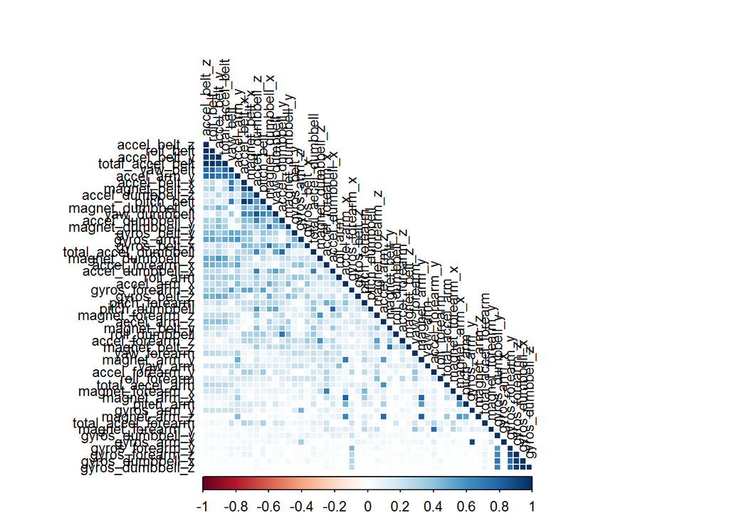

```r
# since column 53 is classe, we will find out correlation of rest of the columns and plot it.
M1 <- abs(cor(subTraining[,-53]))
#diag(M1) <- 0
#which(M1 > 0.8, arr.ind=T)
corrplot(M1, order = "FPC", method = "color", type = "lower", tl.cex = 0.8, tl.col = rgb(0, 0, 0))
```

```r
preProc <- preProcess(subTraining[, -53], method = "pca", thresh = 0.99)
trainPC <- predict(preProc, subTraining[, -53])
valid_testPC <- predict(preProc, subTesting[, -53])
```

##### First prediction model: Using Decision Tree

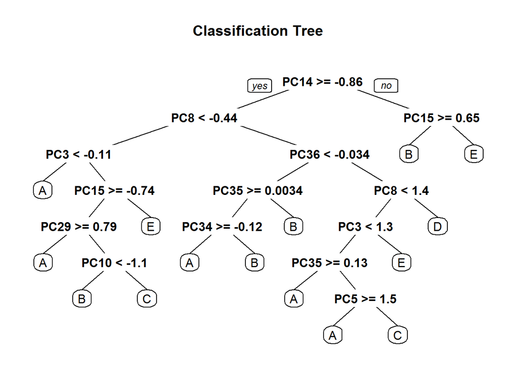

```r
model1 <- rpart(subTraining$classe ~ ., data=trainPC, method="class")
prediction1 <- predict(model1, valid_testPC, type = "class")
rpart.plot(model1, main="Classification Tree", extra=0, under=TRUE, faclen=0)
```

```r
# Test results on our subTesting data set:
confusionMatrix(prediction1, subTesting$classe)
```

```
## Confusion Matrix and Statistics
##
##           Reference
## Prediction    A    B    C    D    E
##          A 1049  230  200   90  147
##          B  121  454  146  156  215
##          C  156  127  436  158  116
##          D   12   49   24  260   46
##          E   57   89   49  140  377
##
## Overall Statistics
##
##                Accuracy : 0.5253
##                  95% CI : (0.5112, 0.5393)
##     No Information Rate : 0.2845
##     P-Value [Acc > NIR] : < 2.2e-16
##
##                   Kappa : 0.3932
##  Mcnemar's Test P-Value : < 2.2e-16
##
## Statistics by Class:
##
##                      Class: A Class: B Class: C Class: D Class: E
## Sensitivity            0.7520  0.47840  0.50994  0.32338  0.41842
## Specificity            0.8099  0.83869  0.86244  0.96805  0.91631
## Pos Pred Value         0.6113  0.41575  0.43907  0.66496  0.52949
## Neg Pred Value         0.8915  0.87015  0.89287  0.87946  0.87500
## Prevalence             0.2845  0.19352  0.17435  0.16395  0.18373
## Detection Rate         0.2139  0.09258  0.08891  0.05302  0.07688
## Detection Prevalence   0.3499  0.22268  0.20249  0.07973  0.14519
## Balanced Accuracy      0.7809  0.65854  0.68619  0.64572  0.66737
```

##### Second prediction model: Using Random Forest

```r
model2 <- randomForest(as.factor(subTraining$classe) ~. , data=trainPC, trControl = trainControl(method = "cv", number = 4), importance=TRUE, ntree=20)

prediction2 <- predict(model2, valid_testPC)
confusionMatrix(prediction2, subTesting$classe)
```

```
## Confusion Matrix and Statistics
##
##           Reference
## Prediction    A    B    C    D    E
##          A 1374   21    1    3    1
##          B    9  900   16    3    6
##          C    3   15  826   23   10
##          D    6    3   10  767    2
##          E    3   10    2    8  882
##
## Overall Statistics
##
##                Accuracy : 0.9684
##                  95% CI : (0.9631, 0.9731)
##     No Information Rate : 0.2845
##     P-Value [Acc > NIR] : < 2e-16
##
##                   Kappa : 0.96
##  Mcnemar's Test P-Value : 0.01117
##
## Statistics by Class:
##
##                      Class: A Class: B Class: C Class: D Class: E
## Sensitivity            0.9849   0.9484   0.9661   0.9540   0.9789
## Specificity            0.9926   0.9914   0.9874   0.9949   0.9943
## Pos Pred Value         0.9814   0.9636   0.9418   0.9734   0.9746
## Neg Pred Value         0.9940   0.9877   0.9928   0.9910   0.9952
## Prevalence             0.2845   0.1935   0.1743   0.1639   0.1837
## Detection Rate         0.2802   0.1835   0.1684   0.1564   0.1799
## Detection Prevalence   0.2855   0.1905   0.1788   0.1607   0.1845
## Balanced Accuracy      0.9888   0.9699   0.9767   0.9744   0.9866
```

##### Decision to choose final model

Accuracy for Random Forest Model is 0.9684 and 95% CI : (0.9631, 0.9731) Accuracy for Decions Tree Model is 0.5253 and 95% CI : (0.5112, 0.5393) Obviously, random forest model is accurate and we choose this model.

##### Importance of variables

Higher the MeanDecreaseAccuracy means how much more helpful the predictor is in reducing classifying error (e.g. from LHS graph below, PC35, PC11 and PC2). Also, listing variable importance for your reference under the graph.

Higher the MeanDecreaseGini means the particular predictor plays a greater role in partitioning the data into defined classes. (e.g. from RHS graph below, PC8, pc35 and pc5 have higher MeanDecreaseGini and are impoartant).

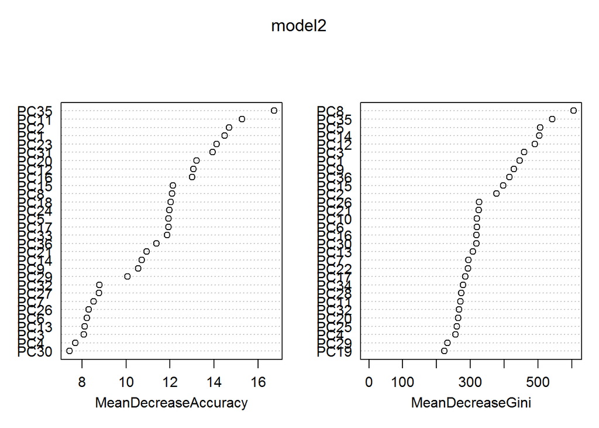

```r
varImpPlot (model2, sort=TRUE)
```

```r
varImp(model2)
```

```
##              A         B         C         D         E
## PC1   7.684607 14.578633 10.820406 12.945743 11.119644
## PC2   8.897309 10.279675  8.102673 11.024230 10.354100
## PC3   7.664457  8.228507  8.294104  8.182337  7.147258
## PC4   6.358604  6.789579  7.625895  8.361273  5.668217
## PC5  11.788641 11.609119 10.573309  9.196258  9.010025
## PC6   7.033762  7.027259  7.573828  6.055060  9.469790
## PC7   5.777286  8.495712  7.688940  8.417937  7.241250
## PC8   9.041511 11.017679  9.785928 11.669982 10.082496
## PC9   6.435933 11.486720  9.453164  9.961913  9.379582
## PC10  5.209684  6.912239  6.418667  6.088630  6.778572
## PC11  7.189396 11.904976  7.450349  8.731871 10.850789
## PC12  9.009249 10.294117 11.799977 10.754852 11.186051
## PC13  5.364763  6.994255  7.859289  7.548616  8.565828
## PC14  9.807061  8.312124 12.736507 11.070440  8.525615
## PC15  8.608397  7.690549  8.731484 10.826092  8.471680
## PC16  9.025231  9.267395 10.204233 11.928308 11.771497
## PC17  6.969107  8.383023  9.882757  9.047766  6.929018
## PC18  6.286281  8.661758  9.110578  8.083648  7.418740
## PC19  5.329741  8.410821  5.798194  6.560579  6.093096
## PC20  9.757122  9.492546  9.673055  9.756259  7.582874
## PC21  9.727409  8.710574  7.614317  9.492928  9.341837
## PC22  4.542500  5.175405  4.740165  6.379326  5.745307
## PC23  8.632684  6.402538  5.302284  7.575781  6.537609
## PC24 10.068376 10.475866  6.397056  5.110984  7.554252
## PC25  5.960992  6.214359  6.139226  7.016947  5.714931
## PC26  5.529592  7.873577  9.749036  8.074379  5.935726
## PC27  4.877430  8.214524  8.055619  7.992152  7.149003
## PC28  5.950291  6.245882  5.806261  7.016193  5.820428
## PC29  7.209474  7.704586  7.709683  8.305994 10.192036
## PC30  7.159078  5.709910  7.442939  5.756803  7.349038
## PC31  6.028833  6.984758  5.599423  6.035460  6.814746
## PC32  8.908941  7.154034  8.520388  6.428591  6.604083
## PC33  7.866178  4.975189 10.153702  8.609724  9.491447
## PC34  6.694875  6.718716  5.991166  5.372492  5.810706
## PC35 12.972101 14.556886 14.651384 17.519327 12.075466
## PC36  7.736364 11.710596 13.919289 12.547116  7.950788
```

##### Cross-validation and out of sample error

Note higher accuracy of our model (96.88%) and small out of sample error based on cross-validation dataset (3.12%).

```r
prediction3 <- predict(model2, valid_testPC)
confus <- confusionMatrix(subTesting$classe, prediction3)
confus$table
```

```
##           Reference
## Prediction    A    B    C    D    E
##          A 1377    7    3    6    2
##          B   20  899   17    3   10
##          C    1   16  825   11    2
##          D    3    3   21  772    5
##          E    1    8   11    3  878
```

```r
# model accuracy for testing data set
accur <- postResample(subTesting$classe, prediction3)
modAccuracy <- accur[[1]]
modAccuracy
```

```
## [1] 0.968801
```

```r
out_of_sample_err <- 1 - modAccuracy
out_of_sample_err
```

```
## [1] 0.03119902
```

##### Final tests on the original test sample provided by the teacher

There are 20 test cases in the original test set. We are writing the output in separate file as requested in the project.

```r
# removing the last column Classe and applying the preprocessing
testPC <- predict(preProc, testingset[, -53])
predictfinal <- predict(model2, testPC)
predictfinal
```

```
##  1  2  3  4  5  6  7  8  9 10 11 12 13 14 15 16 17 18 19 20
##  B  A  B  A  A  E  D  B  A  A  B  C  B  A  E  E  A  B  B  B
## Levels: A B C D E
```

```r
#output to files as mentioned in the proj description
pml_write_files = function(x){
  n = length(x)
  for(i in 1:n){
    filename = paste0("problem_id_",i,".txt")
    write.table(x[i],file=filename,quote=FALSE,row.names=FALSE,col.names=FALSE)
  }
}

pml_write_files(predictfinal)
```